# Lab 09, Experiment 2

```python
%matplotlib inline
from pylab import *
import filtfun as ff
from scipy.signal import butter, lfilter
import showfun as sf
import wavfun as wf
```

# Part (a)

For the Python module keyfun.py, write a function called fskxmtr which implements an M -ary FSK transmitter for either coherent, noncoherent, or continuous phase FSK. The header of this function is shown below. Test fskxmtr by recreating the three (time domain) sample graphs for F B = 100 baud, fc0 = 300 Hz and fc1 = 400 Hz, which were given in the introduction for binary coherent FSK, noncoherent FSK, and CPFSK. Use d n = {0, 1, 1, 1, 0, 0, 1, 0} and (for the second graph) θc [n] = {270, 225 , 4, 135, 250, 90, 40, 240}

```python
def fskxmtr(M,dnthcn,FB,Fs,ptype,pparms,xtype,fcparms):
    """
    M-ary Frequency Shift Keying (FSK) Transmitter for
    Choherent ('coh'), Non-coherent ('noncoh'), and
    Continuous Phase ('cpfsk') FSK Signals
    >>>>> tt,xt = fskxmtr(M,dnthcn,FB,Fs,ptype,pparms,xtype,fcparms) <<<<<
    where  tt:      time axis for x(t), starts at t=-TB/2
    xt:      transmitted FSK signal, sampling rate Fs
    M:       number of distinct symbol values in d[n]
    xtype:   Transmitter type from set {'coh','noncoh','cpfsk'}
    dnthcn = [dn]           for ['coh','cpfsk']
    dnthcn = [dn, thetacn]  for ['noncoh']
    dn:      M-ary (0,1,..,M-1) N-symbol DT input sequence d_n
    thetacn: N-symbol DT sequence theta_c[n] in degrees,
    used instead of thetac0..thetacM-1 for {'noncoh'} FSK
    FB:      baud rate of d_n (and theta_c[n]), TB=1/FB
    Fs:      sampling rate of x(t)
    ptype:   pulse type from set
    {'man','rcf','rect','rrcf','sinc','tri'}
    pparms = []         for {'man','rect','tri'}
    pparms = [k alpha]  for {'rcf','rrcf'}
    pparms = [k beta]   for {'sinc'}
    k:       "tail" truncation parameter for {'rcf','rrcf','sinc'}
    (truncates p(t) to -k*TB <= t < k*TB)
    alpha:   Rolloff parameter for {'rcf','rrcf'}, 0<=alpha<=1
    beta:    Kaiser window parameter for {'sinc'}
    fcparms = [[fc0,fc1,...,fcM-1],[thetac0,thetac1,...,thetacM-1]]
    for {'coh'}
    fcparms = [fc0,fc1,...,fcM-1]  for {'noncoh'}
    fcparms = [fc, deltaf]         for {'cpfsk'}
    fc0,fc1,...,fcM-1:   FSK (carrier) frequencies
    for {'coh','noncoh'}
    thetac0,thetac1,...,thetacM-1: FSK (carrier) phases in deg
    (0: cos, -90: sin) for {'coh'}
    fc:      carrier frequency for {'cpfsk'}
    deltaf:  frequency spacing for {'cpfsk'}
    for dn=0 -> fc, dn=1 -> fc+deltaf,
    dn=2 -> fc+2*deltaf, etc
    """
    if xtype == 'cpfsk':
        fc0 = fcparms[0]
        fc1 = fcparms[1]
    elif xtype == 'coh':
        fc0 = fcparms[0]
        fc1 = fcparms[1]
    else:
        fc0 = fcparms[0][0]
        fc1 = fcparms[0][1]

    if xtype == 'coh':
        di = dnthcn[0]
    else:
        di = dnthcn
    N = len(di)
    TB = 1/float(FB)
    ixL = ceil(-Fs*0.5*TB)
    ixR = ceil(Fs*(N-0.5)*TB)
    tt = arange(ixL,ixR)/float(Fs)

    # ***** Conversion from DT a_n to CT a_s(t) *****
    ast = zeros(len(tt))
    ast1 = zeros(len(tt))
    ix = array(around(Fs*arange(0,N)*TB),int)


    ast[ix-int(ixL)] = Fs*di
    di1 = array([0 if k>0 else 1 for k in di])
    ast1[ix-int(ixL)] = Fs*di1
    if xtype == 'noncoh':
        thetac_n = [float((fcparms[1][k])*pi/180) for k in range(0,len(fcparms[1]))]

    # ***** Set up PAM pulse p(t) *****
    ptype = ptype.lower()

    # Set left/right limits for p(t)
    if (ptype=='rect'):
        kL = -0.5; kR = -kL
    else:
        kL = -1.0; kR = -kL
    ixpL = ceil(Fs*kL*TB)
    ixpR = ceil(Fs*kR*TB)
    ttp = arange(ixpL,ixpR)/float(Fs)
    pt = zeros(len(ttp))
    if (ptype=='rect'):
        ix = where(logical_and(ttp>=kL*TB, ttp<kR*TB))[0]
        pt[ix] = ones(len(ix))
    elif(ptype == 'tri'):
        pt = [(1+((i*1)/TB)) if (1+((i*1)/TB))<1 else (1-((i*1)/TB)) for i in list(ttp)]
    elif(ptype == 'sinc'):
        k=pparms[0]
        kL = -1.0*k
        kR = 1.0*k
        ixpR = ceil(Fs*kR*TB)
        ixpL = ceil(Fs*kL*TB)
        ttp = arange(ixpL,ixpR)/float(Fs)
        pt = zeros(len(ttp))
        beta=pparms[1]
        pt = [(sin(pi*q/TB)/(pi*q/TB)) if q!=0 else 1 for q in list(ttp)]
        pt = pt*kaiser(len(pt),beta)
    elif(ptype=='rcf'):
        k = pparms[0]
        alpha = pparms[1]
        kL = -1.0*k
        kR = 1.0*k
        ixpR = ceil(Fs*kR*TB)
        ixpL = ceil(Fs*kL*TB)
        ttp = arange(ixpL,ixpR)/float(Fs)
        pt = zeros(len(ttp))
        j = 0
        pt = [(sin((pi*q)/TB)/((pi*q)/TB)*(cos(pi*alpha*q/TB)/(1-pow(2*alpha*q/TB,2)))) if q!=0 else 1 for q in list(ttp)]
        ix_nz = where(ttp==-(TB/(2*alpha)))[0]
        ix_pz = where(ttp==(TB/(2*alpha)))[0]
        pt[ix_nz] = (pt[ix_nz+1] + pt[ix_nz-1])/2
        pt[ix_pz] = (pt[ix_pz+1] + pt[ix_pz-1])/2

    elif(ptype=='rrcf'):
        k = pparms[0]
        alpha = pparms[1]
        kL = -1.0*k
        kR = 1.0*k
        ixpR = ceil(Fs*kR*TB)
        ixpL = ceil(Fs*kL*TB)
        ttp = arange(ixpL,ixpR)/float(Fs)
        pt = zeros(len(ttp))
        ixp = where(ttp!=0)[0]
        p = pi*ttp[ixp]/TB
        a = alpha*ttp[ixp]/TB
        pt[ixp] = ((sin((1-alpha)*p) + 4*a*cos((1+alpha)*p))/((1-np.power(4*a,2))*pi*ttp[ixp]))*(TB)
        ix1 = where(ttp==0)[0]
        pt[ix1] = (1-alpha+(4*alpha/pi))
        ix2 = where(ttp==TB/(4*alpha))
        ix3 = where(ttp==-TB/(4*alpha))
        if ix2:
            pt[ix2] = (alpha/2**0.5)*(((1+2/pi)*sin(pi/(4*alpha))) + ((1-2/pi)*cos(pi/(4*alpha))))
            pt[ix3] = (alpha/2**0.5)*(((1+2/pi)*sin(pi/(4*alpha))) + ((1-2/pi)*cos(pi/(4*alpha))))
    elif(ptype=='man'):
        kL = -0.5; kR = -kL
        ixpL = ceil(Fs*kL*TB)
        ixpR = ceil(Fs*kR*TB)
        ttp = arange(ixpL,ixpR)/float(Fs)
        pt = zeros(len(ttp))
        ix = where(logical_and(ttp>=kL*TB, ttp<0))[0]
        pt[ix] = -(ones(len(ix)))
        ix = where(logical_and(ttp>=0, ttp<kR*TB))[0]
        pt[ix] = (ones(len(ix)))
    else:
        print("ptype '%s' is not recognized" % ptype)
    st = convolve(ast,pt)/float(Fs)
    st = st[-int(ixpL):int(ixR-ixL-ixpL)]

    st1 = convolve(ast1,pt)/float(Fs)
    st1 = st1[-int(ixpL):int(ixR-ixL-ixpL)]
    yt = array([])
    if xtype == 'noncoh':
        tt1 = tt[0:int(TB*Fs)]
        for i in range(0,len(di)):
            dt_sym = st[i*(len(tt1)):(i+1)*len(tt1)]*cos((2*pi*fc0*tt1)+thetac_n[i]) + st1[i*(len(tt1)):(i+1)*len(tt1)]*cos((2*pi*fc1*tt1)+thetac_n[i]) #data for each symol
            yt = append(yt,dt_sym)
    elif xtype == 'coh':
        tt1 = tt[0:int(TB*Fs)]
        for i in range(0,len(di)):
            dt_sym = st[i*(len(tt1)):(i+1)*len(tt1)]*cos((2*pi*fc0*tt1)+float(dnthcn[1]*pi/180)) + st1[i*(len(tt1)):(i+1)*len(tt1)]*cos((2*pi*fc1*tt1)+float(dnthcn[1]*pi/180)) #data for each symol
            yt = append(yt,dt_sym)
    elif xtype == 'cpfsk':
        tt1 = tt[int(TB*Fs/2):int(3*TB*Fs/2)]
        for i in range(0,len(di)):
            dt_sym = st[i*(len(tt1)):(i+1)*len(tt1)]*cos((2*pi*fc0*tt1)+float(fcparms[2]*pi/180)) + st1[i*(len(tt1)):(i+1)*len(tt1)]*cos((2*pi*fc1*tt1)+float(fcparms[2]*pi/180)) #data for each symol
            yt = append(yt,dt_sym)
    return tt,yt
```

**Coherent Generation of FSK Symbols**

```python
from pylab import *
M = 2
thetacn = -90
di = array([0,1,1,1,0,0,1,0])
dnhct = [di,thetacn]
FB = 100
Fs = 44100
ptype = 'rect'
pparms = []
xtype = 'coh'
fcparms = [300,400]
tt,st = fskxmtr(M, dnhct, FB, Fs, ptype, pparms, xtype, fcparms)
```

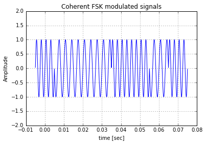

```python
plot(tt,st)
xlabel("time [sec]")
ylabel("Amplitude")
title("Coherent FSK modulated signals")
grid()
ylim([-2,2])
show()
```

**Non-Coherent Generation of FSK Symbols**

```python
from pylab import *
M = 2
thetacn = -90
di = array([0,1,1,1,0,0,1,0])
dnhct = [di,thetacn]
FB = 100
Fs = 44100
ptype = 'rect'
pparms = []
xtype = 'noncoh'
fcparms = [[300,400], [270, 225, 4, 135, 250, 90, 40, 240]]
tt,st = fskxmtr(M, di, FB, Fs, ptype, pparms, xtype, fcparms)
```

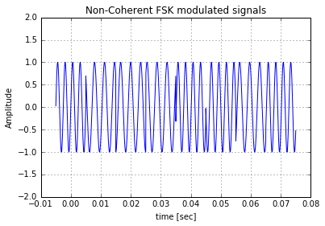

```python
plot(tt,st)
xlabel("time [sec]")
ylabel("Amplitude")
title("Non-Coherent FSK modulated signals")
grid()
ylim([-2,2])
show()
```

# Continuous phase FSK generation

```python
from pylab import *
M = 2
thetacn = -90
di = array([0,1,1,1,0,0,1,0])
dnhct = [di,thetacn]
#di = 2*di-1
FB = 100
Fs = 44100
ptype = 'rect'
pparms = []
xtype = 'cpfsk'
fcparms = [300,400,90]
tt,st = fskxmtr(M, di, FB, Fs, ptype, pparms, xtype, fcparms)
```

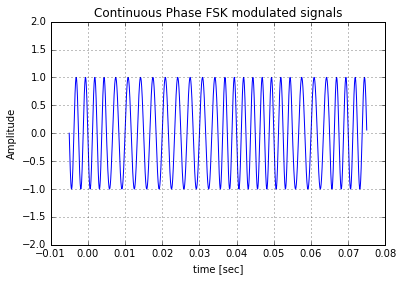

```python
plot(tt,st)
xlabel("time [sec]")
ylabel("Amplitude")
title("Continuous Phase FSK modulated signals")
grid()
ylim([-2,2])
show()
```

# Part (b)

In the keyfun.py module, implement the FSK receiver function fskrcvr whose header is given below. Depending on the choice of the rtype, the receiver should perform demodulation using either M coherent MFs, M MFEDs, or using a phase detctor followed by differentiation and a MF. Test all receiver modes with the signals that you generated in (a) when you were testing fskxmtr.

```python
def fskrcvr(tt, rt, FBparms, FCparms,rtype, ptype, pparms=[]):
    """
    Pulse amplitude modulation receiver with matched filter:
    r(t) -> b(t) -> bn.
    V1.0 for 'man', 'rcf', 'rect', 'rrcf', 'sinc', and 'tri'
    pulse types.
    >>>>> bn, bt, ixn = pamrcvr10(tt, rt, FBparms, ptype, pparms) <<<<<
    where  tt:    time axis for r(t)
    rt:    received (noisy) PAM signal r(t)
    FBparms: = [FB, dly]
    FB:    Baud rate of PAM signal, TB=1/FB
    dly:   sampling delay for b(t) -> b_n as a fraction of TB
    sampling times are t=n*TB+t0 where t0 = dly*TB
    ptype: pulse type from list
    ('man','rcf','rect','rrcf','sinc','tri')
    pparms not used for 'man','rect','tri'
    pparms = [k, alpha]  for 'rcf','rrcf'
    pparms = [k, beta]  for 'sinc'
    k:     "tail" truncation parameter for 'rcf','rrcf','sinc'
    (truncates p(t) to -k*TB <= t < k*TB)
    alpha: rolloff parameter for ('rcf','rrcf'), 0<=alpha<=1
    beta:  Kaiser window parameter for 'sinc'
    bn:    received DT sequence after sampling at t=n*TB+t0
    bt:    received PAM signal b(t) at output of matched filter
    ixn:   indexes where b(t) is sampled to obtain b_n
    """
    Fs = (len(tt)-1)/(tt[-1]-tt[0])
    thetac = 90
    theta = float(thetac*pi/180)
    if rtype == 'coh':
        Fc = FCparms[0]
    elif rtype == 'noncoh' :
        Fc = FCparms[0][0]
    elif rtype == 'cpfsk':
        Fc = FCparms[0]
    else:
        print('Unrecognized rtype')
    carr_sig = cos((2*pi*Fc*tt)+theta)
    rt = rt * carr_sig
    FB = FBparms[0]
    t0 = FBparms[1]

    # ***** Set up matched filter response h_R(t) *****
    TB = 1/float(FB)
    ptype = ptype.lower()

    # Set left/right limits for p(t)
    if (ptype=='rect'):
        kL = -0.5; kR = -kL
    else:
        kL = -1.0; kR = -kL
    ixpL = ceil(Fs*kL*TB)
    ixpR = ceil(Fs*kR*TB)
    ttp = arange(ixpL,ixpR)/float(Fs)
    pt = zeros(len(ttp))
    if (ptype=='rect'):
        ix = where(logical_and(ttp>=kL*TB, ttp<kR*TB))[0]
        pt[ix] = ones(len(ix))
    elif (ptype=='tri'):
        pt = [(1+((i*1)/TB)) if (1+((i*1)/TB))<1 else (1-((i*1)/TB)) for i in list(ttp)]
    elif (ptype=='rcf'):
        k = pparms[0]
        alpha = pparms[1]
        kL = -1.0*k
        kR = 1.0*k
        ixpR = ceil(Fs*kR*TB)
        ixpL = ceil(Fs*kL*TB)
        ttp = arange(ixpL,ixpR)/float(Fs)
        pt = [(sin((pi*q)/TB)/((pi*q)/TB)*(cos(pi*alpha*q/TB)/(1-pow(2*alpha*q/TB,2)))) if q!=0 else 1 for q in list(ttp)]
        ix_nz = where(ttp==-(TB/(2*alpha)))[0]
        ix_pz = where(ttp==(TB/(2*alpha)))[0]
        if (ix_nz !=0):
            pt[ix_nz] = (pt[ix_nz+1] + pt[ix_nz-1])/2
            pt[ix_pz] = (pt[ix_pz+1] + pt[ix_pz-1])/2
    elif (ptype=='sinc'):
        k=pparms[0]
        kL = -1.0*k
        kR = 1.0*k
        ixpR = ceil(Fs*kR*TB)
        ixpL = ceil(Fs*kL*TB)
        ttp = arange(ixpL,ixpR)/float(Fs)
        pt = zeros(len(ttp))
        beta=pparms[1]
        pt = [(sin(pi*q/TB)/(pi*q/TB)) if q!=0 else 1 for q in list(ttp)]
        pt = pt*kaiser(len(pt),beta)
    elif (ptype=='man'):
        kL = -0.5; kR = -kL
        ixpL = ceil(Fs*kL*TB)
        ixpR = ceil(Fs*kR*TB)
        ttp = arange(ixpL,ixpR)/float(Fs)
        pt = zeros(len(ttp))
        ix = where(logical_and(ttp>=kL*TB, ttp<0))[0]
        pt[ix] = -(ones(len(ix)))
        ix = where(logical_and(ttp>=0, ttp<kR*TB))[0]
        pt[ix] = (ones(len(ix)))
    elif (ptype=='rrcf'):
        k = pparms[0]
        alpha = pparms[1]
        kL = -1.0*k
        kR = 1.0*k
        ixpR = ceil(Fs*kR*TB)
        ixpL = ceil(Fs*kL*TB)
        ttp = arange(ixpL,ixpR)/float(Fs)
        pt = zeros(len(ttp))
        ixp = where(ttp!=0)[0]
        p = pi*ttp[ixp]/TB
        a = alpha*ttp[ixp]/TB
        pt[ixp] = ((sin((1-alpha)*p) + 4*a*cos((1+alpha)*p))/((1-np.power(4*a,2))*pi*ttp[ixp]))*(TB)
        ix1 = where(ttp==0)[0]
        pt[ix1] = (1-alpha+(4*alpha/pi))
        ix2 = where(ttp==TB/(4*alpha))[0]
    else:
        print("ptype '%s' is not recognized" % ptype)
    hRt = pt[::-1]
    hRt = Fs/sum(np.power(pt,2.0))*hRt

    # ***** Filter r(t) with matched filter h_R(t)
    bt = convolve(rt,hRt)/float(Fs)
    bt = bt[int(-ixpL):int(len(tt)-ixpL)]

    # ***** Sample b(t) at t=n*TB+t0 to obtain b_n *****
    N = ceil(FB*(tt[-1]-tt[0]))
    ixn = array(around((arange(N)+0.5+t0)*Fs/FB),int)

    ix = where(logical_and(ixn>=0,ixn<len(tt)))[0]
    ixn = ixn[ix]
    bn = bt[ixn]
    bn = [1 if abs(k)>0.01 else 0 for k in bn]
    return bn, bt, ixn
```

**Reception of Coherent FSK**

```python
from pylab import *
M = 2
thetacn = 90
di = array([0,1,1,1,0,0,1,0])
dnhct = [di,thetacn]
FB = 100
Fs = 44100
ptype = 'rect'
pparms = []
FBparms = [FB,0]
FCparms = []
xtype = 'coh'
fcparms = [300,400]
```

```python
tt,st = fskxmtr(M, dnhct, FB, Fs, ptype, pparms, xtype, fcparms)
bn, bt, ixn = fskrcvr(tt, st, FBparms, fcparms,xtype, ptype, pparms=[])
```

```python
bn
```

```
[0, 1, 1, 1, 0, 0, 1, 0]
```

```python
# to check the difference in the modulated bits and demodulated

list(di-bn).count(1)
```

```
0
```

**Our function of coherent FSK is working good as we have got the same sequence after demodulation as the sequence which we modulated.**

**Reception of Non-Coherent FSK**

```python
from pylab import *
M = 2
thetacn = -90
di = array([0,1,1,1,0,0,1,0])
dnhct = [di,thetacn]
FB = 100
Fs = 44100
ptype = 'rect'
pparms = []
xtype = 'noncoh'
fcparms = [[300,400], [270, 225, 4, 135, 250, 90, 40, 240]]
```

```python
tt,st = fskxmtr(M, di, FB, Fs, ptype, pparms, xtype, fcparms)
bn, bt, ixn = fskrcvr(tt, st, FBparms, fcparms,xtype, ptype, pparms=[])
```

```python
bn
```

```
[0, 1, 1, 1, 0, 0, 1, 0]
```

```python
# to check the difference in the modulated bits and demodulated

list(di-bn).count(1)
```

```
0
```

**Our function of non-coherent FSK is working good as we have got the same sequence after demodulation as the sequence which we modulated.**

**Reception of Continuous phase FSK**

```python
from pylab import *
M = 2
thetacn = -90
di = array([0,1,1,1,0,0,1,0])
dnhct = [di,thetacn]
#di = 2*di-1
FB = 100
Fs = 44100
ptype = 'rect'
pparms = []
xtype = 'cpfsk'
fcparms = [300,400,90]
```

```python
tt,st = fskxmtr(M, di, FB, Fs, ptype, pparms, xtype, fcparms)
bn, bt, ixn = fskrcvr(tt, st, FBparms, fcparms,xtype, ptype, pparms=[])
```

```python
bn
```

```
[0, 1, 1, 1, 0, 0, 1, 0]
```

```python
# to check the difference in the modulated bits and demodulated

list(di-bn).count(1)
```

```
0
```

**Our function of continuous phas FSK is working good as we have got the same sequence after demodulation as the sequence which we modulated.**